# Assessment 4: Reproducible Data Analysis Project

Johan Pal U3237699

2023-05-04

# 1-Introduction

#a)Relevant background information of basketball, including key metrics, position requirements etc

This whole assignment is based on the fact to evaluate and get five basketball players with a budget of $118 million. To do so, several key factors need to be considered to evaluate basketball players and teams which are: points per game (PPG), rebounds per game (RPG), assists per game (APG), steals per game (SPG), blocks per game (BPG), and field goal percentage (FG%). In the basketball world, the above-mentioned metrices are used to assess individual player performance & team performance. Moreover, there is also other metrices that are available and commonly used to give comprehensive picture of a player’s value and their impact on the team such as player efficiency rating (PER), true shooting percentage (TS%), and win shares (WS).

Most people, even if they do not watch basketball, know it is a game played with five players on each side of a team, where every player has a different position and role. The different five positions are:

1)Point Guard (PG): known to be the team’s primary ball handler and playmaker, meaning they have a vital role to set up offensive plays and passing the ball to other players. Usually, not deemed necessary point guards are smaller in height and quicker than other players where they are effective on passing the ball, handling the ball, and shooting from a mid-range or after the arc.

2)Shooting Guard (SG): as the name itself implies, known to be the team’s best perimeter shooter and scorer, meaning they have a vital role and responsible in taking high percentage shots which also means they would stretch the defense of the opposite team with their shooting range. Compared to point guards, shooting guards are larger in size and are more athletic where they a focus shooting, cutting, and scoring from mid-range and after the arc.

3)Small Forward (SF): In my opinion, small forwards are basically versatile players or in other words an all-rounder as they can adapt playing both inside and outside as they have the ability and focus on scoring, rebounding, and defending. Compared to shooting guards, they are usually larger in size and more athletic.

4)Power Forward (PF): known to be playing close to the basket and have a focus on scoring, rebounding, and defending within the borders of the arc. Compared with small forwards, are larger in size and more physical.

5)Center (C): known to be the tallest player in basketball as they are the primary defenders and rebounders near the basket. They are as I said the largest in size and most physical players on the team as they focus on scoring, rebounding, and defending within and inside the borders of the arc.

Finally, it is important to know that besides the key metrices, there are other key factors that drag and decrease the overall performance of a player as well as the team in basketball and that includes playing style, coaching strategy, team chemistry, and injury. It’s important to take all these factors into account when analyzing basketball data and making decisions about player recruitment and team strategy.

#b)Description of the scenario

In this scenario, I am a data analyst representing/working for NBA team Chicago Bulls which placed 27th out of 30 teams based on a win-loss record in the season 2018-19. We have a budget of $118 million for player contracts in the upcoming 2019-20 season where we ranked 26th out of 30 teams. My task as a data analyst is to use the budget in an effective manner which we can afford to identify the best five starting players for the team and that can be players that were already playing in Chicago Bulls team in 2018-19 season, of course proving that they are worth the investment.

To tackle such a task, as a data analyst I must collect and analyze data on the performance as well as salaries of NBA players based on the previous season and use it to build a model that can help predict player performance. Based on the model we came up with, identify the top five players for each position our team can afford with the budget.

Overall, the vital goal is to improve team performance in the upcoming season having a budget constraint.

#c)Aim of the project

The aim of such a project is to have the chance of improving and potentially moving up in the league rankings board by relying on key metrices and overall performance of team players in the previous season.

#d)Justification and importance

The justification and importance of such a project lies in the fact that the NBA team Chicago Bulls that was once known to be historically successful in basketball, is currently struggling to maintain its position in the league. Identifying the best five starting players for the team within their budget constraints can help improve its performance and potentially move it up on the league rankings board.

The project is vital because it establishes the value of data-driven decision making in the field of sports, which has become increasingly competitive and financially driven. Use of data analysis can facilitate teams identifying undervalued players, assess the performance of existing players, and make updated decisions about future player purchases.

Moreover, the project can have substantial financial consequences for the team. The NBA has a salary cap, which limits the amount of money a team can spend on player contracts. By identifying the best five starting players within a budget, the Chicago Bulls can improve the spending and potentially avoid costly mistakes in player purchases.

Overall, the project is justified and important because it can benefit Chicago Bulls enhance their performance, increase their competitiveness, and make informed decisions about player purchase within budget constraints.

```r
# 2-Reading and cleaning the raw data

#Loading and installing packages if necessary
if(!require(tidyverse)) install.packages('tidyverse')
```

```r
if(!require(tidyr)) install.packages('tidyr')
if(!require(ggplot2)) install.packages('ggplot2')
if(!require(broom)) install.packages('broom')
# We start by loading and importing csv files into R

nba_playersalaries <- read.csv("2018-19_nba_player-salaries.csv")
nba_playerstats <- read.csv("2018-19_nba_player-statistics.csv")
nba_playerstats1 <- read.csv("2018-19_nba_team-statistics_1.csv")
nba_playerstats2<- read.csv("2018-19_nba_team-statistics_2.csv")
nba_teampayroll <- read.csv ("2019-20_nba_team-payroll.csv")

#Use colSums function to search for missing values in each data frame

colSums(is.na(nba_playersalaries))
```

```
##   player_id player_name      salary
##           0           0           0
```

```r
colSums(is.na(nba_playerstats))
```

```
## player_name         Pos         Age          Tm           G          GS
##           0           0           0           0           0           0
##          MP          FG         FGA         FG.         X3P        X3PA
##           0           0           0           6           0           0
##        X3P.         X2P        X2PA        X2P.        eFG.          FT
##          47           0           0          15           6           0
##         FTA         FT.         ORB         DRB         TRB         AST
##           0          43           0           0           0           0
##         STL         BLK         TOV          PF         PTS
##           0           0           0           0           0
```

```r
colSums(is.na(nba_playerstats1))
```

```
##     Rk   Team    Age      W      L     PW     PL    MOV    SOS    SRS   ORtg
##      0      0      0      0      0      0      0      0      0      0      0
##   DRtg   NRtg   Pace    FTr  X3PAr    TS.   eFG.   TOV.   ORB. FT.FGA   DRB.
##      0      0      0      0      0      0      0      0      0      0      0
##      X    X.1    X.2
##     30     30     30
```

```r
colSums(is.na(nba_playerstats2))
```

```
##   Rk Team    G   MP   FG  FGA  FG.  X3P X3PA X3P.  X2P X2PA X2P.   FT  FTA  FT.
##    0    0    0    0    0    0    0    0    0    0    0    0    0    0    0    0
##  ORB  DRB  TRB  AST  STL  BLK  TOV   PF  PTS
##    0    0    0    0    0    0    0    0    0
```

```r
colSums(is.na(nba_teampayroll))
```

```
## team_id    team  salary
##       0       0       0
```

```r
#Concluded that two datasets need cleaning by either replacing or removing missing values "NA"


#After have done some research and viewing the datasets, I found out that columns "X", "X.1", and "X.2" in "nba_playerstats1" need to be removed as they are just empty columns

#Removing the last three columns using the square bracket notation

nba_playerstats1 <- nba_playerstats1 [,-(23:25)]

#Checking again for clarification

colSums(is.na(nba_playerstats1))
```

```
##     Rk   Team    Age      W      L     PW     PL    MOV    SOS    SRS   ORtg
##      0      0      0      0      0      0      0      0      0      0      0
##   DRtg   NRtg   Pace    FTr  X3PAr    TS.   eFG.   TOV.   ORB. FT.FGA   DRB.
##      0      0      0      0      0      0      0      0      0      0      0
```

```r
#Moreover, there around 5 metrices in "nba_playerstats" that have missing values.

#I began with an approach to check how many times a name of a basketball player has been repeated more than once within the column "player_name" since there is a chance for a player to change teams within a season.

freq_table <- table(nba_playerstats$player_name)

freq_table[freq_table>1]
```

```
##
##              Alec Burks         Andrew Harrison           Austin Rivers
##                       4                       4                       3
##           Avery Bradley              BJ Johnson        Boban Marjanovic
##                       3                       3                       3
##            Bobby Portis          Brandon Knight          Caleb Swanigan
##                       3                       3                       3
##           Cameron Payne          Christian Wood                CJ Miles
##                       3                       3                       3
##            Corey Brewer            Courtney Lee             Dario Saric
##                       3                       3                       3
##          DeAndre Jordan            Delon Wright            Dennis Smith
##                       3                       3                       3
##           Emanuel Terry             Enes Kanter           Eric Moreland
##                       3                       3                       3
##          Garrett Temple             George Hill             Greg Monroe
##                       3                       3                       4
##         Harrison Barnes          Henry Ellenson           Iman Shumpert
##                       3                       3                       3
##           Isaiah Canaan             Ivica Zubac           Jabari Parker
##                       4                       3                       3
##             James Ennis          James Nunnally          JaMychal Green
##                       3                       3                       3
##             Jason Smith             Jawun Evans              Jeremy Lin
##                       4                       3                       3
##            Jimmy Butler            John Jenkins       Jonas Valanciunas
##                       3                       3                       3
##        Jonathon Simmons          Justin Holiday          Justin Jackson
##                       3                       3                       3
##             Kelly Oubre          Kenneth Faried             Kyle Korver
##                       3                       3                       3
##           Landry Shamet              Marc Gasol         Markieff Morris
##                       3                       3                       3
##         Marquese Chriss     Matthew Dellavedova Michael Carter-Williams
##                       3                       3                       3
##            Mike Muscala              Mike Scott             Mitch Creek
##                       3                       3                       3
##            Nik Stauskas          Nikola Mirotic             Otto Porter
##                       3                       3                       3
##           Patrick McCaw               Pau Gasol            Ray Spalding
##                       3                       3                       3
##          Reggie Bullock        Robert Covington             Rodney Hood
##                       3                       3                       3
##               Ron Baker           Ryan Anderson              Sam Dekker
##                       3                       3                       3
##            Shelvin Mack         Skal Labissiere         Stanley Johnson
##                       3                       3                       3
##   Sviatoslav Mykhailiuk              Thon Maker             Tim Frazier
##                       3                       3                       3
##            Tim Hardaway Timothe Luwawu-Cabarrot           Tobias Harris
##                       3                       3                       3
##            Trevor Ariza              Trey Burke            Tyler Dorsey
##                       3                       3                       3
##           Tyler Johnson            Tyler Zeller          Tyson Chandler
##                       3                       3                       3
##         Wayne Ellington            Wayne Selden          Wesley Johnson
##                       3                       3                       3
##         Wesley Matthews         Wilson Chandler
##                       4                       3
```

```r
#Concluded that some players have their name written more than once
#Decided on creating a new data frame and choosing the last row for player names that have been repeated because the metrices are accumulating when a player is changing from one team to another.

nba_playerstats_new <- nba_playerstats %>%
  group_by(player_name) %>%
  slice(which.max(G)) %>%
  ungroup()


#Check if there are missing values in the new created data frame

colSums(is.na(nba_playerstats_new))
```

```
## player_name         Pos         Age          Tm           G          GS
##           0           0           0           0           0           0
##          MP          FG         FGA         FG.         X3P        X3PA
##           0           0           0           4           0           0
##        X3P.         X2P        X2PA        X2P.        eFG.          FT
##          36           0           0          10           4           0
##         FTA         FT.         ORB         DRB         TRB         AST
##           0          27           0           0           0           0
##         STL         BLK         TOV          PF         PTS
##           0           0           0           0           0
```

```r
#Concluded that five metrices have NA values

#After careful visualization and scanning the new data frame,it was clear that NA values appeared when a formula was used meaning in case of "X3P." the formula is X3P/X3PA and when both X3P & X3PA are zero the final value of "X3P." is showing as "NA". Same applies for the rest of the metrices like "FG.", "X2P.","eFG.", and "FT.".

#Decided to replace NA values with zero.

nba_playerstats_new[is.na(nba_playerstats_new)] <- 0

#Checking again if there are NA values

colSums(is.na(nba_playerstats_new))
```

```
## player_name         Pos         Age          Tm           G          GS
##           0           0           0           0           0           0
##          MP          FG         FGA         FG.         X3P        X3PA
##           0           0           0           0           0           0
##        X3P.         X2P        X2PA        X2P.        eFG.          FT
##           0           0           0           0           0           0
##         FTA         FT.         ORB         DRB         TRB         AST
##           0           0           0           0           0           0
##         STL         BLK         TOV          PF         PTS
##           0           0           0           0           0
```

```r
#Create new processed folder in directory to store the processed data

if(!dir.exists("processed")){
  dir.create("processed")
}


#Create data frames to CSV files in the processed folder
write.csv(nba_playerstats_new, file = "processed/nba_playerstats_new.csv", row.names = FALSE)
write.csv(nba_playersalaries , file = "processed/nba_playersalaries .csv", row.names = FALSE)
write.csv(nba_playerstats1, file = "processed/nba_playerstats1.csv", row.names = FALSE)
write.csv(nba_playerstats2, file = "processed/nba_playerstats2.csv", row.names = FALSE)
write.csv(nba_teampayroll, file = "processed/nba_teampayroll.csv", row.names = FALSE)



#Since there are five different positions we have to choose from I decided to create five different data frames in order to get a better understanding of the players and their performance


pg_data <- subset(nba_playerstats_new, nba_playerstats_new$Pos == "PG")
pf_data <- subset(nba_playerstats_new,nba_playerstats_new$Pos == "PF")
sf_data <- subset(nba_playerstats_new,nba_playerstats_new$Pos == "SF")
sg_data <- subset(nba_playerstats_new,nba_playerstats_new$Pos == "SG")
c_data <- subset(nba_playerstats_new,nba_playerstats_new$Pos == "C")


#Since we also have the option to choose players that are already in the Chicago Bulls team . I decided to create two different data frames one for salary and one for the stats and then merged them into one data frame.

nba_playersalaries_new <- merge(nba_playersalaries,nba_playerstats_new[,c("player_name","Tm")], by = "player_name",all.x = TRUE)

nba_playersalaries_new <- subset(nba_playersalaries_new, !is.na(Tm))


chicago_bulls_stats <- subset(nba_playerstats_new, Tm == "CHI")

chicago_bulls_salaries <- subset(nba_playersalaries_new, Tm == "CHI")

chicago_bulls_merged <- merge(chicago_bulls_stats, chicago_bulls_salaries, by = "player_name")
```

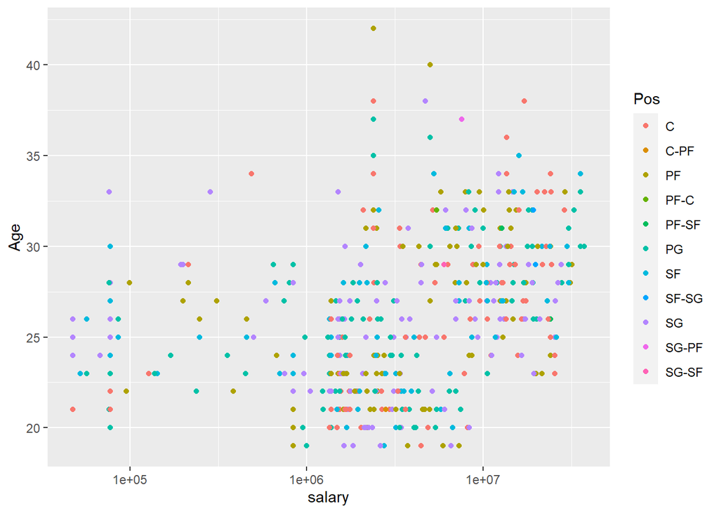

```r
# 3-Exploratory Analysis

#EDA is a crucial and vital step in order to gain insight of different variables within a data frame

#Example 1- Checking relation between salary, age, and position

nba_playerstats_new <- merge(nba_playerstats_new,nba_playersalaries, by = "player_name")


nba_playerstats_new%>%  ggplot(aes(salary, Age , color = Pos)) +
  geom_point() +
  scale_x_log10()
```

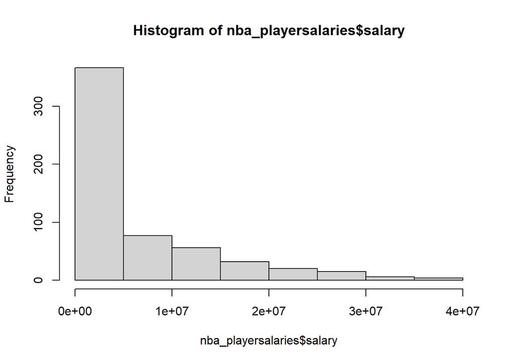

```r
#This graph clearly shows that there is no pattern of playing position that influences salary. One can also assume that as long as a player is skilled they will have definetly have a high salary no matter their age or position.


#Example 2- Salary of NBA players distribution


hist(nba_playersalaries$salary)
```

```r
#The skewness of the histogram of salaries proves to us and indicates that few players have high salaries and this indicates outliers which at a later stage can be evaluated in a linear model

#Example 3- Checking structure of "nba_teampayroll" data set

str(nba_teampayroll)
```

```
## 'data.frame':    30 obs. of  3 variables:
##  $ team_id: int  1 2 3 4 5 6 7 8 9 10 ...
##  $ team   : chr  "Miami " "Golden State " "Oklahoma City " "Toronto " ...
##  $ salary : chr  "$153,171,497 " "$146,291,276 " "$144,916,427 " "$137,793,831 " ...
```

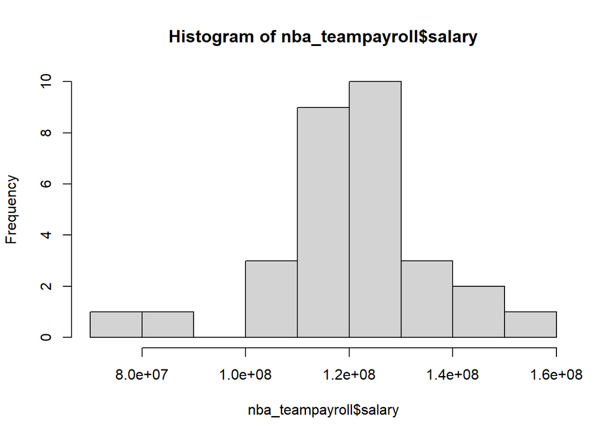

```r
#Remove $ sign in the teampayroll dataset for later use to build a histogram
nba_teampayroll$salary <- gsub("\\$|,", "", nba_teampayroll$salary)

#Converting from character to numeric to use in order to build a  histogram

nba_teampayroll$salary  <- as.numeric(nba_teampayroll$salary )

hist(nba_teampayroll$salary)
```

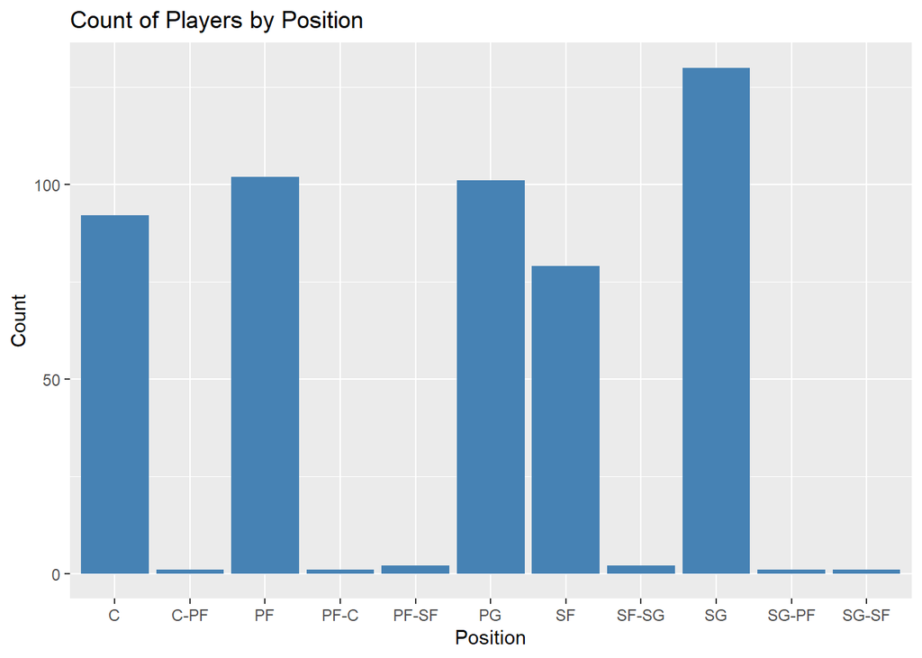

```r
#Concluded that it is approximately normally distributed meaning the budget of different NBA team is close to one another.


# Example 4- Viewing the count of players for all five positions

# Count players by position
pos_count <- table(nba_playerstats_new$Pos)

# Convert to data frame
pos_count_df <- data.frame(Position = names(pos_count), Count = as.vector(pos_count))

# Create bar plot
ggplot(pos_count_df, aes(x = Position, y = Count)) +
  geom_bar(stat = "identity", fill = "steelblue") +
  ggtitle("Count of Players by Position")
```

```r
# The graph shows that the count for shooting guards is the highest.
```

#4- Data Modelling & results

Data modelling to select players can be a vital step because it can help detect patterns and relations between different player attributes and their performance on the court. By analyzing data, teams can identify key factors that provide to success, such as shooting accuracy, rebounding ability, and defensive skills.

By use of the information, we can develop different models to predict how players will most likely perform in the future all based on their past performance, not to forget other factors that can also affect like injuries or if a player is going to start in a game or not.

The model in this way would help teams make knowledgeable decisions about which players to sign or trade for, as well as help trainers and directors develop strategies to adjust player performance on the court. Overall, data modelling and results can give valuable insights into player performance and benefit teams make more informed decisions, ultimately leading to better team performance and greater success on the court.

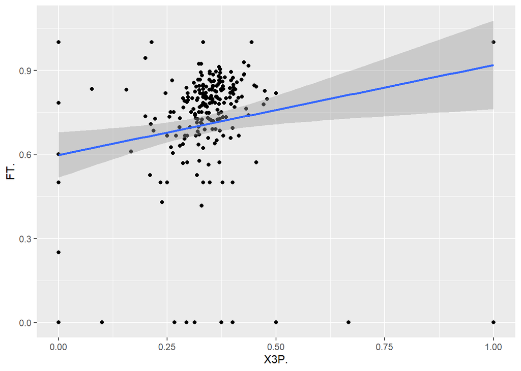

```r
# 4-Data modelling and results

# a) data modelling (e.g. creating a linear regression)

#First Model

#Point Guards And Shooting Guards


#There are a few possible options for us to choose for x and y in the Exploratory data analysis in order to decide on a point guards and shooting guards. I am building a model on both together because they have similar factor to predict player performances for these position. My approach to building the model was that both PG and SG are two main dragging factors for teams to increase when it comes to scoring. Therefore, metrices like 3 points is considered to be on top of the list as it is the most important factor to increase the scoreboard quickly.

#Begin by merging the two data frames pg_data and sg_data together

pg_sg_merge <- subset(nba_playerstats_new,nba_playerstats_new$Pos %in% c("PG", "SG"))

#Add subject ID column to be used later in modeling

pg_sg_merge$subject_id <- 1:nrow(pg_sg_merge)

#Assists per game for (x) and Points per game for (y): This can help identify point guards and shooting guards who excel at setting up their teammates for scoring opportunities, while also being able to score themselves.

#Steals per game for (x) and Turnovers per game for (y): This can help identify point guards and shooting guards who are skilled at creating turnovers on defense, but may also be prone to making mistakes with the ball on offense.

#Three-point percentage for (x) and Free-throw percentage for (y): This can help identify point guards and shooting guards who are strong shooters from beyond the arc and at the free-throw line, which are both important skills for scoring and closing out games.

#I would personally be conducting the last option because I have mentioned before three point is an important factor as well free throws as they are considered brownie points in the basketball world

#relationship between 3 point percentage and free throw percentage for point guard and shooting guard data

ggplot(data = pg_sg_merge, aes(x = X3P., y = FT.)) +
  geom_point() +
  geom_smooth(method = "lm")
```

```r
#Create linear regression to model X3P. (3 point percentage) based on assists,turnovers, field goal percentage, points, minutes played, & steals.

model <- lm(X3P. ~ AST + TOV +
            FG. + FT. +
            PTS + MP +
            STL, data = pg_sg_merge)
tidy(model, conf.int = TRUE)
```

```
## # A tibble: 8 × 7
##   term          estimate std.error statistic  p.value   conf.low conf.high
##   <chr>            <dbl>     <dbl>     <dbl>    <dbl>      <dbl>     <dbl>
## 1 (Intercept) -0.0608    0.0346       -1.76  8.06e- 2 -0.129     0.00746
## 2 AST         -0.0000731 0.000128     -0.572 5.68e- 1 -0.000325  0.000179
## 3 TOV         -0.000384  0.000361     -1.07  2.88e- 1 -0.00109   0.000326
## 4 FG.          0.872     0.0743       11.7   4.39e-25  0.725     1.02
## 5 FT.          0.0406    0.0321        1.26  2.07e- 1 -0.0227    0.104
## 6 PTS          0.0000433 0.0000447     0.968 3.34e- 1 -0.0000448 0.000131
## 7 MP           0.0000177 0.0000257     0.689 4.92e- 1 -0.0000329 0.0000682
## 8 STL         -0.000195  0.000488     -0.399 6.90e- 1 -0.00116   0.000767
```

```r
# Print model summary
summary(model)
```

```
##
## Call:
## lm(formula = X3P. ~ AST + TOV + FG. + FT. + PTS + MP + STL, data = pg_sg_merge)
##
## Residuals:
##      Min       1Q   Median       3Q      Max
## -0.52105 -0.02460  0.01064  0.04114  0.47909
##
## Coefficients:
##               Estimate Std. Error t value Pr(>|t|)
## (Intercept) -6.079e-02  3.464e-02  -1.755   0.0806 .
## AST         -7.313e-05  1.278e-04  -0.572   0.5678
## TOV         -3.841e-04  3.605e-04  -1.065   0.2879
## FG.          8.719e-01  7.429e-02  11.736   <2e-16 ***
## FT.          4.063e-02  3.213e-02   1.265   0.2073
## PTS          4.330e-05  4.473e-05   0.968   0.3341
## MP           1.767e-05  2.565e-05   0.689   0.4918
## STL         -1.948e-04  4.882e-04  -0.399   0.6903
## ---
## Signif. codes:  0 '***' 0.001 '**' 0.01 '*' 0.05 '.' 0.1 ' ' 1
##
## Residual standard error: 0.1049 on 223 degrees of freedom
## Multiple R-squared:  0.4258, Adjusted R-squared:  0.4078
## F-statistic: 23.63 on 7 and 223 DF,  p-value: < 2.2e-16
```

```r
#Independence

car::durbinWatsonTest(model)
```

```
##  lag Autocorrelation D-W Statistic p-value
##    1      0.05244615      1.894111   0.442
##  Alternative hypothesis: rho != 0
```

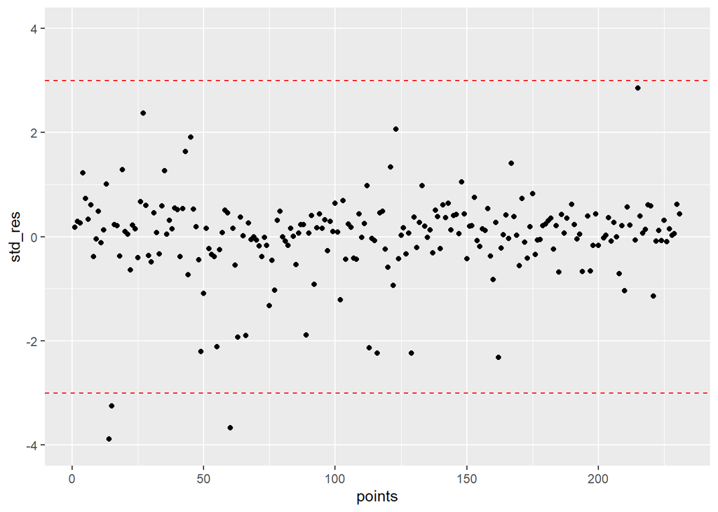

```r
#Outliers

std_res <- rstandard(model)

points <- 1:length(std_res)

ggplot(data = NULL, aes(x = points, y = std_res)) +
  geom_point() +
  ylim(c(-4,4)) +
  geom_hline(yintercept = c(-3, 3), colour = "red", linetype = "dashed")
```

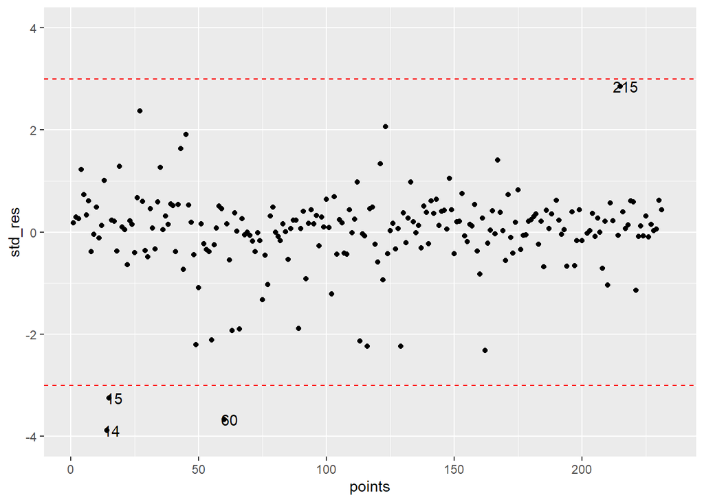

```r
# there could be some outliers here as some points are close to 3


res_labels <- if_else(abs(std_res) >= 2.5, paste(points), "")

ggplot(data = NULL, aes(x = points, y = std_res, label = res_labels)) +
  geom_point() +
  geom_text(nudge_x = 2) +
  ylim(c(-4,4)) +
  geom_hline(yintercept = c(-3, 3), colour = "red", linetype = "dashed")
```

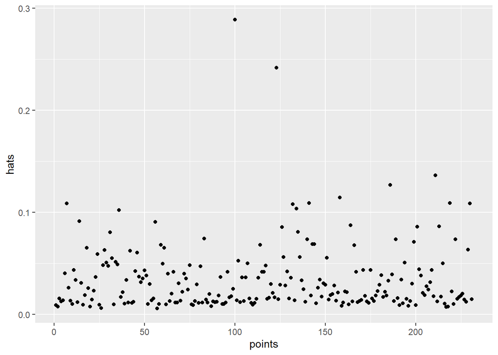

```r
#Leverage points

#Determining any high leverage points that have the potential to influence the model


hats <- hatvalues(model)

ggplot(data = NULL, aes(x = points, y = hats)) +
  geom_point()
```